# Text mining our way into Taylor Swift: A Story through Data

Nacho Pulido Ruiz

2023-03-04

## Context

A close friend who happens to be a Taylor Swift fan is asking for our help in order to understand the evolution of the singer in terms of her lyrics and song messages. We will gather information on each of her songs, the release date and the album to which each song pertains and carry out computational analysis to tell our story.

Opening hypothesis: With extremely limited previous knowledge about Taylor´s songs, we will be taking advantage of a range of text mining tools in order to understand better the song topics of such a worldwide successful artist. As an opening theory, we will stick to the conjecture that she plays with the theme of love in most of her songs (this could apply to many singers nowadays). Even though not being a declared fan (a Swiftie), one cannot escape from listening to many of her songs in TV adds, the radio, youtube playlists etc. Since her popularity and achievements are so outstanding, we could guess that her music suits a wide majority of the audience (mainly pop music). However, let´s begin with our project and study these views deeper!

Our departure point will be to load the required libraries for the analysis.

```r
library(tidyverse)
```

```r
library(tidytext)
library(stringr)
library(wordcloud)
library(igraph)
library(ggraph)
library(widyr)
```

Where we will obtain our data from: https://www.kaggle.com/datasets/PromptCloudHQ/taylor-swift-song-lyrics-from-all-the-albums

```r
#read csv file
lyrics <- read.csv("taylor_swift_lyrics.csv")

lyrics <- lyrics %>%
  #Split all the tokens and care for punctuation
  unnest_tokens(word,lyric, drop = TRUE,
                "strip_punct" = TRUE) %>%
  #We select only the columns we are interested in
  select(album,track_title,year,word)
head(lyrics)
```

```
##          album track_title year word
## 1 Taylor Swift  Tim McGraw 2006   he
## 2 Taylor Swift  Tim McGraw 2006 said
## 3 Taylor Swift  Tim McGraw 2006  the
## 4 Taylor Swift  Tim McGraw 2006  way
## 5 Taylor Swift  Tim McGraw 2006   my
## 6 Taylor Swift  Tim McGraw 2006 blue
```

```r
lyrics %>%
  filter(word == "trouble")
```

```
##    album             track_title year    word
## 1    Red I Knew You Were Trouble 2012 trouble
## 2    Red I Knew You Were Trouble 2012 trouble
## 3    Red I Knew You Were Trouble 2012 trouble
## 4    Red I Knew You Were Trouble 2012 trouble
## 5    Red I Knew You Were Trouble 2012 trouble
## 6    Red I Knew You Were Trouble 2012 trouble
## 7    Red I Knew You Were Trouble 2012 trouble
## 8    Red I Knew You Were Trouble 2012 trouble
## 9    Red I Knew You Were Trouble 2012 trouble
## 10   Red I Knew You Were Trouble 2012 trouble
## 11   Red I Knew You Were Trouble 2012 trouble
## 12   Red I Knew You Were Trouble 2012 trouble
## 13   Red I Knew You Were Trouble 2012 trouble
## 14   Red I Knew You Were Trouble 2012 trouble
## 15   Red I Knew You Were Trouble 2012 trouble
## 16   Red I Knew You Were Trouble 2012 trouble
## 17   Red I Knew You Were Trouble 2012 trouble
## 18   Red I Knew You Were Trouble 2012 trouble
## 19   Red I Knew You Were Trouble 2012 trouble
## 20   Red I Knew You Were Trouble 2012 trouble
## 21   Red I Knew You Were Trouble 2012 trouble
## 22   Red I Knew You Were Trouble 2012 trouble
## 23   Red I Knew You Were Trouble 2012 trouble
## 24   Red I Knew You Were Trouble 2012 trouble
```

```r
lyrics <- lyrics %>%
  #anti_join will keep the rows where words don´t match our stopwords
  anti_join(stop_words)
head(lyrics)
```

```
##          album track_title year    word
## 1 Taylor Swift  Tim McGraw 2006    blue
## 2 Taylor Swift  Tim McGraw 2006    eyes
## 3 Taylor Swift  Tim McGraw 2006  shined
## 4 Taylor Swift  Tim McGraw 2006 georgia
## 5 Taylor Swift  Tim McGraw 2006   stars
## 6 Taylor Swift  Tim McGraw 2006   shame
```

## Frequency analysis

We will perform some simple statistical analysis to begin with. It might be interesting to calculate the frequency of appearance of each word in the whole course of Taylor´s music trajectory and plot the results. In literary studies, analyzing word frequency can provide insights into an author’s writing style, as well as the historical and cultural context in which the work was written. In this case, these techniques will be applied to Taylor´s songs:

```r
taylor_words <- lyrics %>%
  #group dataframe by words (many are repeated over and over in different albums/songs)
  group_by(word) %>%
  #count the number of appearances
  count() %>%
  #sort in a descending order
  arrange(desc(n)) %>%
  ungroup()
taylor_words
```

```
## # A tibble: 1,957 × 2
##    word      n
##    <chr> <int>
##  1 time    164
##  2 love    160
##  3 baby    115
##  4 ooh     103
##  5 stay     88
##  6 wanna    82
##  7 shake    80
##  8 yeah     80
##  9 ey       72
## 10 night    72
## # … with 1,947 more rows
```

Now that we have a clean and ordered frequency table, let´s take all these words and visualize them. We will resort to a wordcloud such that it will enable us to spot with ease which are the most outstanding words in terms of statistical ocurrence. This is the reason why we loaded the library *wordcloud* at the beginning. The most commonly used words are displayed in larger fonts and are typically placed at the center of the cloud, while less frequently used words are displayed in smaller fonts and placed around the periphery of the cloud.

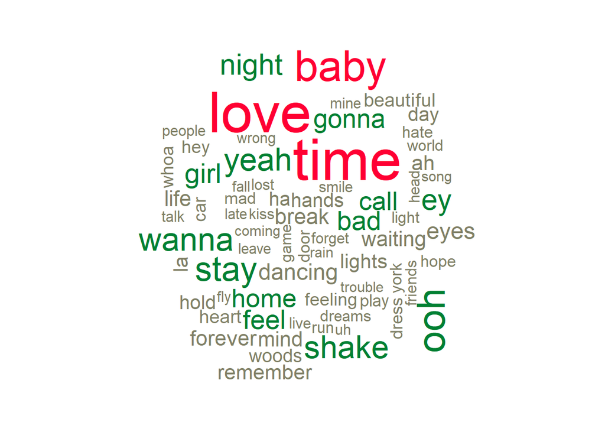

```r
taylor_words %>%
  #bring the data into wordcloud, set to 70 the maximum words to avoid overlapping
  with(wordcloud(word,n,max.words = 70,
                 #set rgb colors in green, dark grey and red
                 colors = c(rgb(0.5,0.5,0.4),
                            rgb(0,0.5,0.2),
                 rgb(1,0,0.2))))
```

We notice that the the most common words in Taylor Swift´s songs are time, love or baby. We infer that the singer is devoting much of her time to write about love and maybe the time taken to let go a past relation. These words are then followed in the background by words like “feel”, “kiss”, “home” or “girl”, which goes in line with our previous analysis such that her whole discography seems to be designed to speak about girl feelings, romance and the sensation of being at “home” or at ease. We do find some other interesting words like “mad”, “forever”, “hate” or “wrong”, which means that there is some degree of anger or pain expressed in her songs.

Let´s perform a similar analysis but segmenting by album:

```r
top_words <- lyrics %>%
  #We group each word with its album
  group_by(album,word) %>%
  #We count the number of ocurrences
  count() %>%
  #Sort in a descending order
  arrange(album,desc(n)) %>%
  #Just keeo the grouping by album
  ungroup(word) %>%
  #Slice the top 6 results
  slice(1:6) %>%
  ungroup()
top_words
```

```
## # A tibble: 36 × 3
##    album    word      n
##    <chr>    <chr> <int>
##  1 1989     shake    78
##  2 1989     ey       72
##  3 1989     love     60
##  4 1989     baby     42
##  5 1989     woods    38
##  6 1989     stay     33
##  7 Fearless la       26
##  8 Fearless feel     21
##  9 Fearless baby     17
## 10 Fearless mm       16
## # … with 26 more rows
```

Now, let´s enter this new tibble into *ggplot()* and make and alternative representation of word ocurrence:

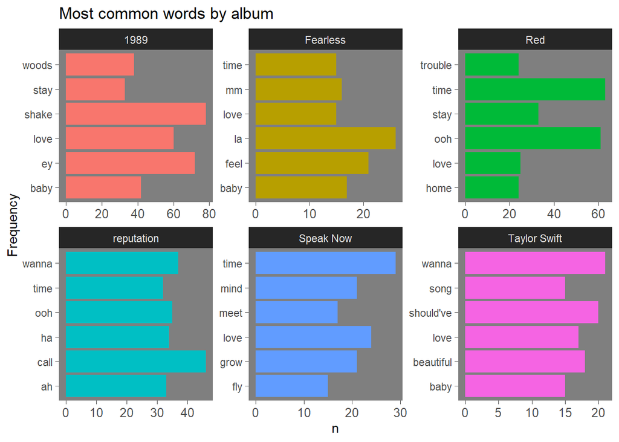

```r
top_words %>%
  #Enter data into ggplot2
  ggplot()+
  #Choose the aesthetics and fill by each album
  aes(n,word, fill = album)+
  #Set the identity stat
  geom_bar(stat = "identity")+
  #facet by group (album)
  facet_wrap(~album, scales = "free")+
  #Set some themes and rename the axis
  theme_dark()+
  theme(axis.text.x = element_text(size = 10),
        legend.position = "None",
        #Vanish grid lines
        panel.grid = element_blank())+
  labs(y = "Frequency", title = "Most common words by album")
```

## Sentiment analysis

Now we will analyse her lyrics by resorting to a sentiment analysis. We will first take advantage of *afinn* which is based on a regression analysis on sentiment and assigns a value from [-3,3] to each word. A sentiment analysis enables us to automatically identify and extract subjective information from text data. It involves analyzing the lyrics to determine the overall sentiment or attitude of the artist, whether positive, negative, or neutral. We will group by song in order to perform a net sentiment (sum of all positive and negative values) analysis and plot our results.

```r
afinn <- lyrics %>%
  #join with afinn words list
  inner_join(get_sentiments("afinn")) %>%
  #group by song in chronological order
  group_by(track_title,year) %>%
  #summarise the net value
  summarise(net_sentiment = sum(value)) %>%
  #sort by time
  arrange(year) %>%
  ungroup()
afinn
```

```
## # A tibble: 94 × 3
##    track_title                    year net_sentiment
##    <chr>                         <int>         <dbl>
##  1 A Perfectly Good Heart         2006            37
##  2 A Place In This World          2006             7
##  3 Cold as You                    2006           -17
##  4 I'm Only Me When I'm With You  2006             0
##  5 Invisible                      2006            29
##  6 Mary's Song (Oh My My My)      2006            16
##  7 Our Song                       2006             5
##  8 Picture To Burn                2006           -48
##  9 Should've Said No              2006             1
## 10 Stay Beautiful                 2006            59
## # … with 84 more rows
```

Time for our plot:

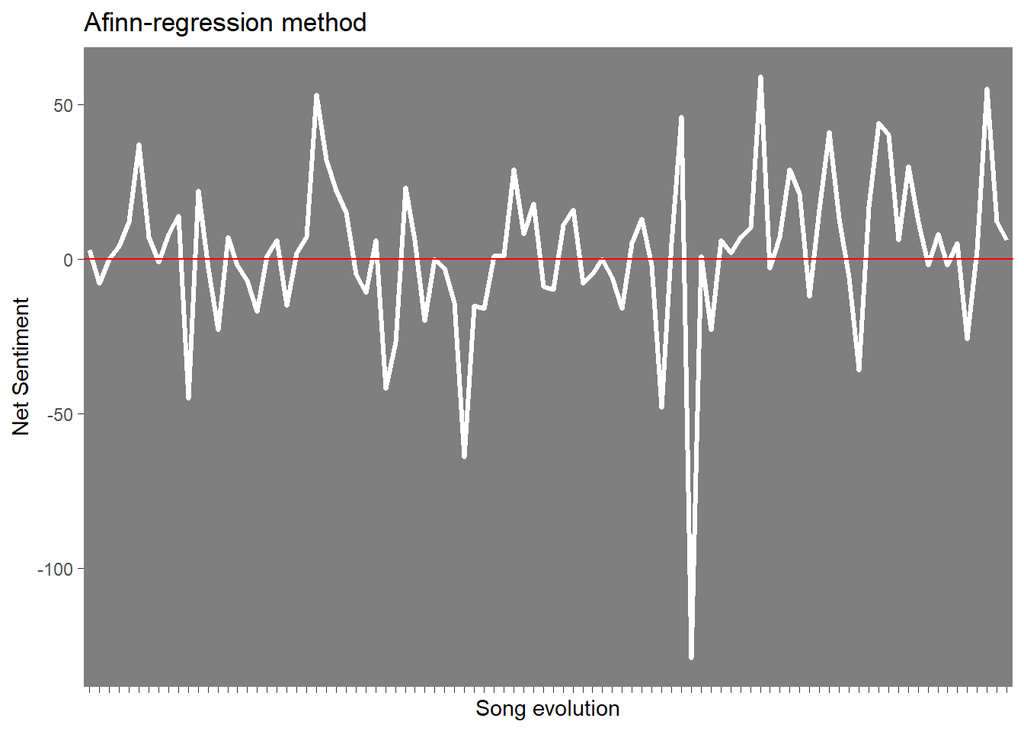

```r
afinn %>%
  #Enter information in ggplot
  ggplot()+
  #choose song and net sentiment as aesthetics
  aes(track_title,net_sentiment)+
  #plot with points and vanish them setting some transparency
  geom_point(alpha = 0)+
  #set white lines
  geom_line(group = 1, color = "white", size = 1.2)+
  #set some labels for the plot axis and title
  labs(y = "Net Sentiment", x = "Song evolution", title = "Afinn-regression method")+
  #dark theme with no grid lines
  theme_dark()+
  theme(axis.text.x = element_blank(),
        panel.grid = element_blank())+
  #add a division with a horizontal line
  geom_abline(slope = 0, intercept =  0, color = "red")
```

We see that, for each song, values above 0 indicate a positive net sentiment whereas values below the 0 red line refer to a negative sentiment. The first thing we notice is that net sentiment results often span roughly from [-50,50], so we can deduce that, independent on the sign, taylor inputs a lot of passion and descriptive words into her songs. However, there is an outlier pointing at an extreme negative sentiment towards the right-end of the graph. It might be interesting to us to explore what this value is and why is this taking place:

```r
afinn %>%
  filter(net_sentiment == min(net_sentiment))
```

```
## # A tibble: 1 × 3
##   track_title   year net_sentiment
##   <chr>        <int>         <dbl>
## 1 Shake It Off  2014          -129
```

The song outlier is Shake it off, from 2014, with a net sentiment of -129. Let´s explore this lyrics:

```r
lyrics %>%
  #filter by song title
  filter(track_title == "Shake It Off") %>%
  #join with afinn list to see our words
  inner_join(get_sentiments("afinn")) %>%
  #get just negative words
  filter(value < 0) %>%
  #group by word and count the frequency
  group_by(word) %>%
  count() %>%
  #sort
  arrange(desc(n))
```

```
## # A tibble: 9 × 2
## # Groups:   word [9]
##   word       n
##   <chr>  <int>
## 1 fake      18
## 2 hate      16
## 3 haters     4
## 4 stop       4
## 5 dirty      2
## 6 cheats     1
## 7 liars      1
## 8 miss       1
## 9 sick       1
```

Now we have an answer to what we extracted from our plot analysis. This song happens to repeat up to 18 times the word “fake” and uses another 16 times the word “hate”.

Recall we have been using the *afinn* method up to now, but we will take advantage now of *bing* to explore a similar plot by year. Bing contains 2 levels for each word, “positive” and “negative”.

```r
bing <- lyrics %>%
  #join with list of words in bing
  inner_join(get_sentiments("bing")) %>%
  #group by the sentiment and year and count the frequency
  group_by(year,sentiment) %>%
  count() %>%
  #set to wider format by reshaping the data
  pivot_wider(names_from = sentiment,
              values_from = n) %>%
  #calculate net value of the count
  mutate(net_sentiment = positive-negative)
bing
```

```
## # A tibble: 6 × 4
## # Groups:   year [6]
##    year negative positive net_sentiment
##   <int>    <int>    <int>         <int>
## 1  2006      130       98           -32
## 2  2008       91      104            13
## 3  2010      197      145           -52
## 4  2012      225      166           -59
## 5  2014      330      131          -199
## 6  2017      210      181           -29
```

Now we have clean and easy-to-read information on the net sentiment by year waiting to be plotted!

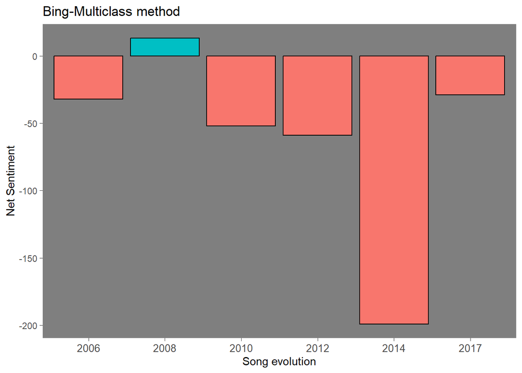

```r
bing %>%
  #bring information into ggplot
  ggplot()+
  #transform year to a factor for plotting purposes
  aes(as.factor(year),net_sentiment, fill = net_sentiment>0)+
  #take bars as geometries with the usual stat
  geom_bar(stat = "identity", color = "black")+
  #take some axis labels
  labs(y = "Net Sentiment", x = "Song evolution", title = "Bing-Multiclass method")+
  #dark theme with no grid lines
  theme_dark()+
  theme(axis.text.x = element_text(size = 10),
        panel.grid = element_blank(),
        legend.position = "none")
```

It is interesting to notice that Taylor is more on the side of a pessimistic view in her songs since we observe a lingering negative sentiment along time. There is only one year in which the positive charge outweighs the negative one which is in 2008. On that year, at the age of 19, the artist became the biggest-selling solo artist of the year with more than 7 million albums sold.

### Most common positive and negative words

We will determine the contribution of each word in the vector of songs to each sentiment by analyzing how often each word appears in the songs and which sentiment it is associated with.

```r
#create a data frame with word, sentiment and number of mentions
bing_word_counts <- lyrics %>%
  #get sentiment from bing
  inner_join(get_sentiments("bing")) %>%
  #count the number of mentions for each word
  count(word, sentiment, sort = TRUE) %>%
  ungroup()
bing_word_counts %>% head()
```

```
##        word sentiment   n
## 1      love  positive 160
## 2     shake  negative  80
## 3       bad  negative  63
## 4     break  negative  49
## 5 beautiful  positive  38
## 6      whoa  positive  34
```

As usual, we pipe this information into ggplot to have a better visualization of these words:

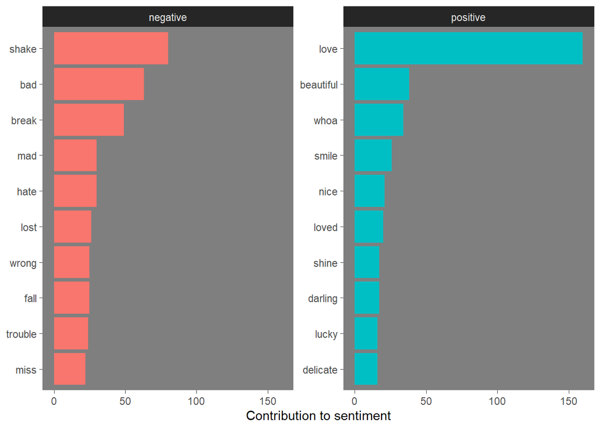

```r
bing_word_counts %>%
  group_by(sentiment) %>%
  #obtain top 10 results
  slice_max(n, n = 10) %>%
  ungroup() %>%
  #reorder for plotting purposes
  mutate(word = reorder(word, n)) %>%
  #select aesthetics
  ggplot(aes(n, word, fill = sentiment)) +
  geom_col(show.legend = FALSE) +
  #facet by sentiment (only two categories in this case)
  facet_wrap(~sentiment, scales = "free_y") +
  labs(x = "Contribution to sentiment",
       y = NULL)+
  theme_dark()+
  #drop panel grid lines
  theme(panel.grid = element_blank())
```

It becomes quite obvious for the user that the term “love” is not only one of the most frequently resorted words by Taylor in all her songs, but it is also the word which contributes, by far, the most to the positive sentiment in her songs. However, notice we are not analysing (yet) the preceding term accompanying “love”, and this could change the meaning significantly. We will explore bigrams and enhance our analysis later in the project.

On the side of negative sentiment, we find that the words “bad”, “loss” or “hate” are one of the biggest contributors of such a sentiment, which confirms our hypothesis of Taylor exploring the theme on past personal relationships with boys which didn´t go as expected. Up to now, all our analysis is pointing in the same direction, byt let´s find out if one is able to extract more relevant information on the following sections.

## Term frequency and IDF

Now we will upgrade the word frequency analysis into a more scientific method. We have already counted the words appearing the most in each of the albums, but one would like a measure of distinctiveness. A word is distinctive of a document if its appearance in such a file is more often relative to the rest of the documents. We will analyse these metrics by album and plot the results to find useful patterns. A high IDF score for a particular term indicates that the term is relatively rare or unique within the corpus (takes place in just a few songs or albums), and is therefore more important. The TF-IDF score for a term within a document is calculated by multiplying the term frequency by the inverse document frequency.

In order to call the function *bind_tf_i*, we will first have to compute the three corresponding columns which enter as arguments:

```r
lyrics_idf <- lyrics %>%
  #We group by album and word
  group_by(album,word) %>%
  #Count how many observations
  count() %>%
  #Ungroup at the end
  ungroup()
```

Now we can enter this information into the tf_idf function and obtain the top 10 records:

```r
lyrics_idf_top <- lyrics_idf %>%
  #calculate the corresponding metrics
  bind_tf_idf(word,album,n) %>%
  #arrange from highest to lowest tf_idf
  arrange(album,desc(tf_idf)) %>%
  #group by each album
  group_by(album) %>%
  #obtain top records
  slice(1:10)
#vizualise results
lyrics_idf_top %>%
  head()
```

```
## # A tibble: 6 × 6
## # Groups:   album [1]
##   album word           n      tf   idf tf_idf
##   <chr> <chr>      <int>   <dbl> <dbl>  <dbl>
## 1 1989  ey            72 0.0375  1.79  0.0672
## 2 1989  woods         38 0.0198  1.79  0.0355
## 3 1989  shake         78 0.0406  0.693 0.0282
## 4 1989  wonderland    21 0.0109  1.79  0.0196
## 5 1989  york          27 0.0141  1.10  0.0155
## 6 1989  blood         16 0.00834 1.79  0.0149
```

The tf_idf compensates for the amount of documents (in this case, albums) holding the term inside it while at the same time it increases in relation to the number of times such a document contains the specific term. This means that, for a word to be distinctive of a document, it must be in relation to the whole collection of albums and not just to a specific album/song. This differs from the analysis on word frequency we performed at the beginning of the project.

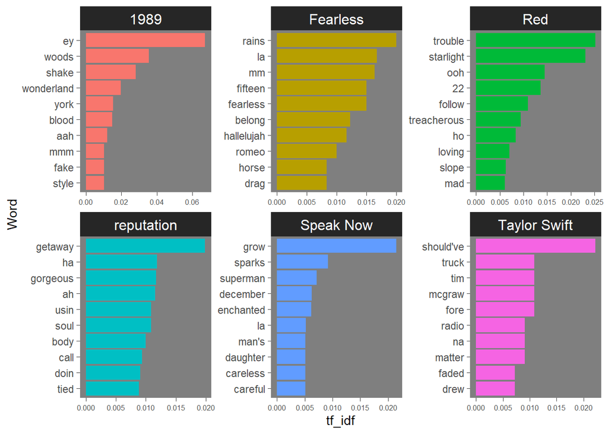

```r
lyrics_idf_top %>%
  #Enter information into ggplot()
  ggplot()+
  #Select tf_idf and word as aesthetics with a reordering parameter
  aes(tf_idf, reorder_within(word,tf_idf,album),fill = album) +
  #Set stat to identity
  geom_bar(stat = "identity")+
  #facet by album
  facet_wrap(~album, scales = "free")+
  labs(y = "Word")+
  #Dark theme with more readable facet titles
  theme_dark()+
  theme(axis.text.x = element_text(size = 6),
        panel.grid = element_blank(),
        legend.position = "none",
        strip.text = element_text(color = "white",size = 12))+
  #Apply scaling to make it more readable for user
  scale_y_reordered()
```

One finds that words that are distinctive of each album are terms like “grow”, “getaway”,“trouble” or “rains”. We have now learnt that “trouble”, which we saw was repeated several times at the sentiment analysis, it pertains to album “Red” and it is actually distinctive of this album. This means that it is overused inside this album with respect to other albums. However, we do find many words which happen to have a high tf_idf but without any specific meaning such as “ho”, “la” or “mm”.

Let´s filter these words and repeat the analysis by generating our proper stopwords:

```r
#Generat personalized stopwords
our_stopwords <- c("ey","aah","la","mm","ooh","ha","na","ho")
lyrics_idf <- lyrics_idf %>%
  #anti join with our stopwords
  anti_join(data.frame(word = our_stopwords))
lyrics_idf_top <- lyrics_idf %>%
  #compute idf metrics again
  bind_tf_idf(word,album,n) %>%
  #arrange in descending order
  arrange(album,desc(tf_idf)) %>%
  group_by(album) %>%
  #fins top 10 records
  slice(1:10)
```

Now we can enter this information again in our plot and see if there is any significant change:

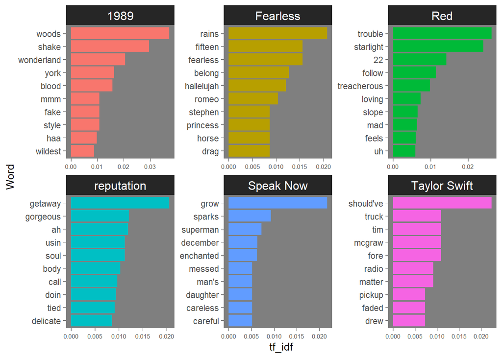

```r
lyrics_idf_top %>%
  #Enter information into ggplot()
  ggplot()+
  #Select tf_idf and word as aesthetics with a reordering parameter
  aes(tf_idf, reorder_within(word,tf_idf,album),fill = album) +
  #Set stat to identity
  geom_bar(stat = "identity")+
  #facet by album
  facet_wrap(~album, scales = "free")+
  labs(y = "Word")+
  #Dark theme with more readable facet titles
  theme_dark()+
  theme(axis.text.x = element_text(size = 6),
        panel.grid = element_blank(),
        legend.position = "none",
        strip.text = element_text(color = "white",size = 12))+
  #Apply scaling to make it more readable for user
  scale_y_reordered()
```

Notice that we don´t find anymore the cloud of words which we described in our personalized stop words. Word “fearless” is distinctive of the album “fearless” (makes sense) and words like “careful”, “enchanted” or “sparks” are distincttive of album “Speak now”, which means that this must be an album centered in speaking about maybe some confusing or frustrating love experience and someone that “messed” with her -> gives rise to the title of this album, “Speak now” and tell the world.

Now we will perform a small analysis on the words that were the most common at the start of the project. We will analyze if words that were repeated so frequently in each album hold, at the same time, a relatively high measure of tf_idf:

```r
lyrics_idf %>%
  #compute metrics
  bind_tf_idf(word,album,n) %>%
  #filter for specific words
  filter(word %in% c("time","love","call","feel","baby","home","shake")) %>%
  #arrange in a descending order
  arrange(album,desc(tf_idf))
```

```
## # A tibble: 37 × 6
##    album    word      n       tf   idf   tf_idf
##    <chr>    <chr> <int>    <dbl> <dbl>    <dbl>
##  1 1989     shake    78 0.0427   0.693 0.0296
##  2 1989     baby     42 0.0230   0     0
##  3 1989     feel      7 0.00383  0     0
##  4 1989     home     14 0.00766  0     0
##  5 1989     love     60 0.0328   0     0
##  6 1989     time     11 0.00602  0     0
##  7 Fearless call      3 0.00290  0.405 0.00118
##  8 Fearless shake     1 0.000968 0.693 0.000671
##  9 Fearless baby     17 0.0165   0     0
## 10 Fearless feel     21 0.0203   0     0
## # … with 27 more rows
```

Notice how the majority of these words, although repeated frequently inside Taylor´s albums, they hold a very small (even 0) tf_idf metrics. This phenomenon takes place because, if a term happens to be overused on every album, then this word will not be distinctive of any album due to the definition of tf_idf. The only exception seems to be the word “shake” which is slightly distinctive of the album “1989”.

### Zipf’s law

It is a good chance to explore Zipf´s law inside Taylor Swift´s albums. This law states that the frequency of word appearance will be inversely proportional to its rank, so we shall find a clear negative trend when analyzing this (logarithmic) relation:

```r
rank <- lyrics_idf %>%
  #compute idf metrics
  bind_tf_idf(word,album,n) %>%
  #arrange in descending order
  arrange(desc(tf)) %>%
  #group by album
  group_by(album) %>%
  #create column accounting for rank
  mutate(rank = row_number()) %>%
  ungroup()
rank
```

```
## # A tibble: 3,389 × 7
##    album        word          n     tf   idf  tf_idf  rank
##    <chr>        <chr>     <int>  <dbl> <dbl>   <dbl> <int>
##  1 1989         shake        78 0.0427 0.693 0.0296      1
##  2 Red          time         63 0.0384 0     0           1
##  3 1989         love         60 0.0328 0     0           2
##  4 reputation   call         46 0.0240 0.405 0.00975     1
##  5 1989         baby         42 0.0230 0     0           3
##  6 Taylor Swift wanna        21 0.0214 0     0           1
##  7 1989         woods        38 0.0208 1.79  0.0373      4
##  8 Taylor Swift should've    20 0.0204 1.10  0.0224      2
##  9 Fearless     feel         21 0.0203 0     0           1
## 10 Red          stay         33 0.0201 0     0           2
## # … with 3,379 more rows
```

Now we can plot these results by changing the scales into a logarithmic one:

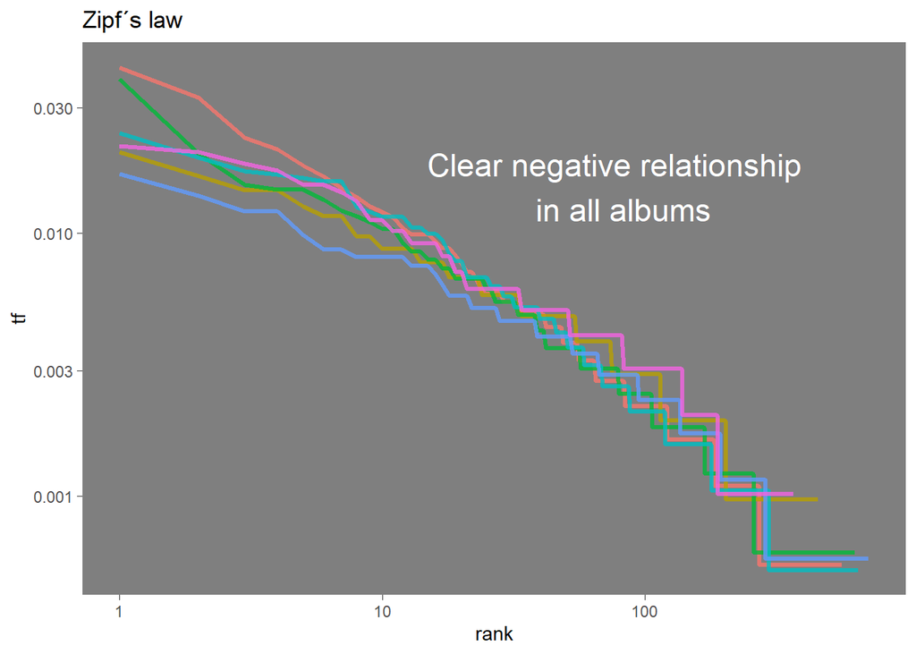

```r
rank %>%
  ggplot(aes(rank, tf, color = album)) +
  #Choose geometry as a line
  geom_line(size = 1.2, alpha = 0.8, show.legend = FALSE) +
  #change scales to logarithmic
  scale_x_log10() +
  scale_y_log10()+
  #set a dark theme
  theme_dark()+
  theme(panel.grid = element_blank())+
  labs(title = "Zipf´s law")+
  #annotations to add comprehension for the user
  annotate("text", label = "Clear negative relationship \n in all albums",
           x = 80, y = 0.015, color = "white", size = 6)
```

## N-grams and word context

Up to now, we have been dealing with individual words or tokens inside Taylor Swift songs, but this limits our analysis and we might lose some context since one might be interested in chunks of words arranged together or appearing close to each other in a given context. N-grams are a technique used in natural language processing and computational linguistics to represent text as a sequence of contiguous words. An n-gram is a contiguous sequence of n items from a given sample of text, where an item can be a word, a character, or a symbol.

Let´s read from scratch our lyric data:

```r
lyrics <- read.csv("taylor_swift_lyrics.csv")
lyrics %>%
  head()
```

```
##         artist        album track_title track_n
## 1 Taylor Swift Taylor Swift  Tim McGraw       1
## 2 Taylor Swift Taylor Swift  Tim McGraw       1
## 3 Taylor Swift Taylor Swift  Tim McGraw       1
## 4 Taylor Swift Taylor Swift  Tim McGraw       1
## 5 Taylor Swift Taylor Swift  Tim McGraw       1
## 6 Taylor Swift Taylor Swift  Tim McGraw       1
##                                         lyric line year
## 1         He said the way my blue eyes shined    1 2006
## 2 Put those Georgia stars to shame that night    2 2006
## 3                      I said, "That's a lie"    3 2006
## 4                 Just a boy in a Chevy truck    4 2006
## 5        That had a tendency of gettin' stuck    5 2006
## 6                       On backroads at night    6 2006
```

We resort to our function *unnest_tokens()* and we choose n = 2 to operate with bigrams. Since we are dealing with songs, higher order n-grams might not be as interesting, so we take the decision to work with bigrams in this scenario:

```r
lyrics_bigrams <- lyrics %>%
  # set ngrams in tokenising function
  unnest_tokens(bigram,lyric, token = "ngrams",n = 2)
head(lyrics_bigrams)
```

```
##         artist        album track_title track_n line year    bigram
## 1 Taylor Swift Taylor Swift  Tim McGraw       1    1 2006   he said
## 2 Taylor Swift Taylor Swift  Tim McGraw       1    1 2006  said the
## 3 Taylor Swift Taylor Swift  Tim McGraw       1    1 2006   the way
## 4 Taylor Swift Taylor Swift  Tim McGraw       1    1 2006    way my
## 5 Taylor Swift Taylor Swift  Tim McGraw       1    1 2006   my blue
## 6 Taylor Swift Taylor Swift  Tim McGraw       1    1 2006 blue eyes
```

Let´s perform a first exploration on our bigrams by arranging them by frequency of appearance:

```r
lyrics_bigrams %>%
  #group by all bigrams and count frequencies
  group_by(bigram) %>%
  count() %>%
  #arrange in descending order
  arrange(desc(n))
```

```
## # A tibble: 10,397 × 2
## # Groups:   bigram [10,397]
##    bigram       n
##    <chr>    <int>
##  1 and i      189
##  2 in the     156
##  3 what you   105
##  4 oh oh      103
##  5 i know      96
##  6 i don't     95
##  7 i i         83
##  8 on the      79
##  9 i was       76
## 10 but i       75
## # … with 10,387 more rows
```

We can already infer there are many bigrams containing common terms to song lyrics such as " oh oh" or “ey ey” which means that Taylor takes advantage of many musical rhythms and catchy expressions in her songs. We notice many bigrams which are not relevant at all, we shall filter stop words. To do this, we must first separate into different columns the information on each bigram to keep the results not included in the vector of stopwords.

```r
bigrams_sep <- lyrics_bigrams %>%
  # separate into two different columns and separate by a space
  separate(bigram, c("word1","word2"), sep = " ") %>%
  #filter stopwords in both of these columns
  filter(!word1 %in% stop_words$word) %>%
  filter(!word2 %in% stop_words$word)
bigrams_sep %>%
  head()
```

```
##         artist        album track_title track_n line year   word1  word2
## 1 Taylor Swift Taylor Swift  Tim McGraw       1    1 2006    blue   eyes
## 2 Taylor Swift Taylor Swift  Tim McGraw       1    1 2006    eyes shined
## 3 Taylor Swift Taylor Swift  Tim McGraw       1    2 2006 georgia  stars
## 4 Taylor Swift Taylor Swift  Tim McGraw       1    4 2006   chevy  truck
## 5 Taylor Swift Taylor Swift  Tim McGraw       1    5 2006  gettin  stuck
## 6 Taylor Swift Taylor Swift  Tim McGraw       1    9 2006     tim mcgraw
```

Now we can have a more thorough look at the most common bigrams in Taylor´s lyrics without the “noise” generated by stopwords:

```r
bigrams_sep %>%
  #group by both words and count frequencies
  group_by(word1,word2) %>%
  count() %>%
  #arrange in descending order
  arrange(desc(n))
```

```
## # A tibble: 945 × 3
## # Groups:   word1, word2 [945]
##    word1   word2     n
##    <chr>   <chr> <int>
##  1 ey      ey       54
##  2 ooh     ooh      51
##  3 <NA>    <NA>     51
##  4 la      la       35
##  5 shake   shake    26
##  6 stay    stay     23
##  7 getaway car      22
##  8 ha      ha       17
##  9 ooh     whoa     17
## 10 uh      uh       17
## # … with 935 more rows
```

We notice many bigrams containing terms like “whoa”, “ooh” or “oh”, which alings with what we mentioned before on musicality and rhythm. It is also worth noticing that, although many bigrams seem to appear as a regular basis, it might be the case that these words appear by themselves repeated many times just to add flow or tempo to the song. Let´s see an example!

```r
bigrams_sep %>%
  # Filter by word "ey"
  filter(word1 == "ey") %>%
  #check for distinct cases
  distinct(word1,word2) %>%
  #select relevant columns
  select(word1,word2)
```

```
##   word1 word2
## 1    ey    ey
```

We notice how word “ey” just appears in a single bigram which is no other than this word repeated twice. This happens frequently in Taylor´s songs with other terms we have already seen like “hate” or “fake” since it is a common technique in songs to take advantage of repetition to enable listeners to remember better her songs. We have now learnt something we didn`t know before such that we have discovered a periodic use of this musical dexterity in Taylor´s career.

### Improve tf_idf with bigrams

Incorporating bigrams into our TF-IDF analysis can help us extract more relevant information from the text data, and gain a deeper understanding of the underlying patterns and structures in the lyrics. Recall we had performed word frequencies and tf_idf taks on individual terms, but we will extend this analysis to our already built bigrams to improve our project:

```r
bigrams_idf <- bigrams_sep %>%
  #merge together both columns into a single bigram
  unite(bigram, word1,word2, sep = " ") %>%
  #group by album and bigram and count frequencies
  group_by(album,bigram) %>%
  count() %>%
  #Our function for tf_idf analysis is called
  bind_tf_idf(bigram,album,n) %>%
  #arrange in descending order
  arrange(desc(tf_idf))
head(bigrams_idf) %>%
  ungroup()
```

```
## # A tibble: 6 × 6
##   album        bigram          n     tf   idf tf_idf
##   <chr>        <chr>       <int>  <dbl> <dbl>  <dbl>
## 1 1989         ey ey          54 0.0987 1.79  0.177
## 2 Fearless     mm mm          14 0.0680 1.79  0.122
## 3 reputation   getaway car    22 0.0549 1.79  0.0983
## 4 1989         shake shake    26 0.0475 1.79  0.0852
## 5 Red          ooh ooh        49 0.119  0.693 0.0826
## 6 Taylor Swift wanna break     8 0.0435 1.79  0.0779
```

We can already see that our previously analyzed bigram “ey ey” has turned out to be very distinctive of album “1989” and “wanna break” is the most relevant and distinctive bigram on Taylor´s first album “Taylor Swift”. This tells us additional information on how she started her career and it suggests that she was already prepared for that “break” and tell the world about her stories in the shape of music.

Let´s help the reader and plot this results in a single graph by album:

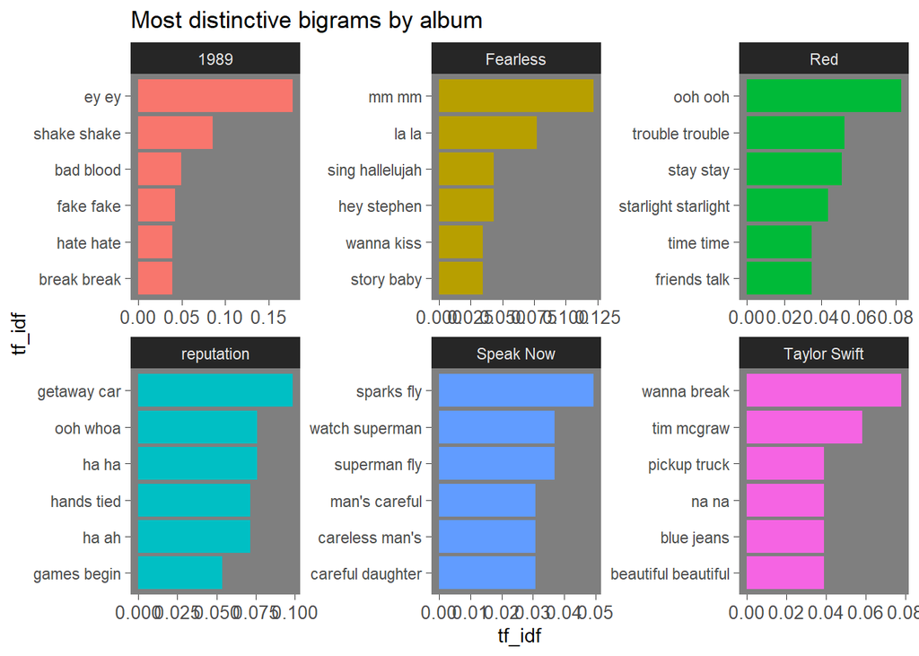

```r
bigrams_idf %>%
  #arrange by descending order in terms of td_idf
  arrange(album,desc(tf_idf)) %>%
  #group by album and obtain top results
  group_by(album) %>%
  slice(1:6) %>%
  ggplot()+
  #Choose the aesthetics and fill by each album
  aes(tf_idf,reorder_within(bigram,tf_idf,album), fill = album)+
  #Set the identity stat
  geom_bar(stat = "identity")+
  #facet by group (album)
  facet_wrap(~album, scales = "free")+
  #Set some themes and rename the axis
  theme_dark()+
  theme(axis.text.x = element_text(size = 10),
        legend.position = "None",
        #Vanish grid lines
        panel.grid = element_blank())+
  labs(y = "tf_idf", title = "Most distinctive bigrams by album")+
  #apply scale reordering
  scale_y_reordered()
```

We can easily notice which are the th most distinctive bigrams in Taylor´s albums and in the corresponding order. We can already start to see some proper names like “Tim Mcgraw” and many of these cases which we saw before in which a word is commonly repeated to make it stand out and make the listener stick the song in his/her head. Some examples are:

- na na -break break
- oh oh
- stay stay
- trouble trouble

### Network of bigrams

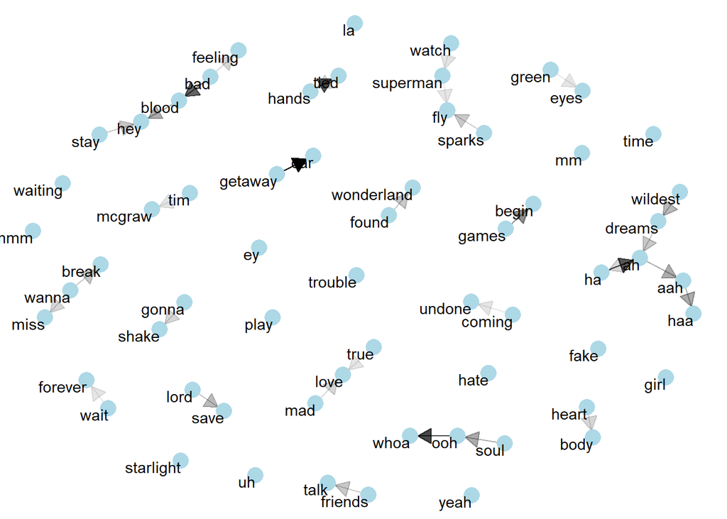

```r
graph <- bigrams_sep %>%
  #count bigram frequencies
  count(word1,word2) %>%
  #filter for top results
  filter(n>5) %>%
  #remove any missing values
  drop_na() %>%
  graph_from_data_frame()
#set seed to obtain always the same plot
set.seed(123)
#set the arrows
a <- grid::arrow(type = "closed", length = unit(0.15,"inches"))
bigram_graph <- ggraph(graph, layout = "fr") +
  # links without legend and end circles
  geom_edge_link(aes(edge_alpha = n), show.legend = FALSE,
                 arrow = a, end_cap = circle(.07, 'inches')) +
  #blue nodes of size 5
  geom_node_point(color = "lightblue", size = 5) +
  geom_node_text(aes(label = name), vjust = 1, hjust = 1) +
  #set the theme, void in this case
  theme_void()
  bigram_graph
```

We can already see some words appearing together such as “true” and “love” or “body” and “heart”, but we might be more interested in the context than in words that are necessarily next to each other.

What are the most frequent words accompanying the word “love”? This is one of the most frequent words found at word frequency counts we analyzed at earlier stages. To do this, we will explore both words coming after and before the word “love”, or bigrams containing such a term.

While our previous word frequency analysis looked at individual words and their frequency of use, bigram analysis incorporates the co-occurrence of pairs of words and their frequency of use together.

By analyzing the frequency of bigrams (in combination with word frequency), we can gain insights into the ways in which words are used in combination with each other, and identify common word combinations or phrases that are used frequently within a text. This can help us better understand the overall meaning and structure of Taylor´s songs, as well as the singer’s style and tone.

```r
love1 <- bigrams_sep %>%
  # filter for love in first word
  filter(word1 == "love") %>%
  count(word1,word2)
love2 <- bigrams_sep %>%
  #filter for love in second word
  filter(word2 == "love") %>%
  count(word1,word2)
# merge together both datasets
love <- rbind(love1,love2)
head(love)
```

```
##   word1  word2 n
## 1  love affair 5
## 2  love   left 2
## 3  love  makes 2
## 4  love  story 5
## 5  love struck 1
## 6  love   till 1
```

let´s make a plot of the most frequent bigrams in which the word “love” is included. To do this, we will unite these two columns in one and reorder the result sorted by frequency. Labels of bigrams will be included with a white background in order to be able to read with ease those terms:

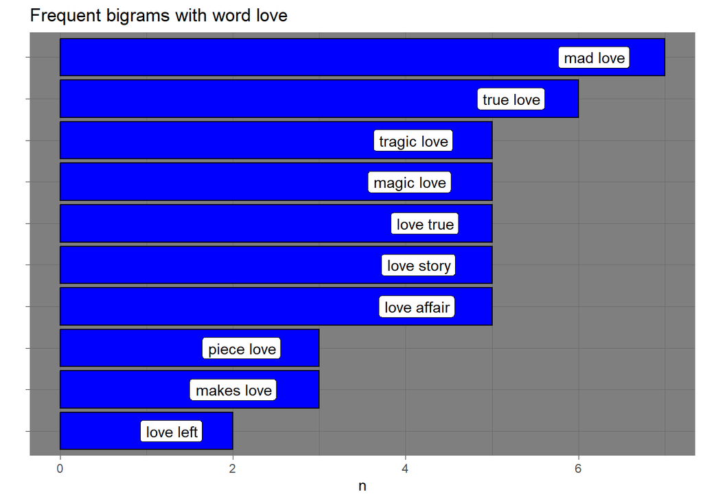

```r
love %>%
  #arrange in descending order
  arrange(desc(n)) %>%
  #obtain top 10 results
  slice(1:10) %>%
  #merge both column attributes in one
  unite(bigram, word1,word2, sep = " ") %>%
  ggplot()+
  #reorder the result by frequency of appearance
  aes(n, reorder(bigram,n))+
  #set color styles and stat on geometry
  geom_bar(stat = "identity", color = "black", fill = "blue")+
  theme_dark()+
  #set a title
  labs(y = " ", title = "Frequent bigrams with word love")+
  theme(axis.text.y = element_blank())+
  #include labels to see each bigram
  geom_label(aes(label = bigram), hjust = 1.5)
```

The most common bigrams including this term are “mad love”, “true love” and “tragic love”. This means that, althought one of Taylor´s major topics in her songs is love, she often refers to a bitter love which may not be as positive as we might think just with a sole wording analysis. We can also notice bigrams such as “love story” or “love affair”, so we conclude that she is telling, once again, her past love experiences which have not been successful or have a component of resentment.

### Word correlation and phi coefficient

We will first count the number of times two words appear under the same context (recall we have grouped by songs and we have more than 90 songs in total). To do this, we resort to the function *pairwise_count()* which counts the number of times each pair of items appear together within a group defined by “feature.” Under this context, the features are our song titles:

```r
lyrics %>%
  #tokenize
  unnest_tokens(word,lyric) %>%
  #remove stopwords
  anti_join(stop_words) %>%
  #calculate pairwise count with grouping by song
  pairwise_count(word,track_title, sort = TRUE)
```

```
## # A tibble: 230,328 × 3
##    item1 item2     n
##    <chr> <chr> <dbl>
##  1 love  time     25
##  2 time  love     25
##  3 time  night    22
##  4 night time     22
##  5 time  eyes     16
##  6 love  eyes     16
##  7 eyes  time     16
##  8 eyes  love     16
##  9 mind  love     16
## 10 love  mind     16
## # … with 230,318 more rows
```

The most common word appearences under the same context (song) are “time” with “love”, “time” with “night” and the term “eyes” with many other of the previous terms. This means that these terms are commonly linked together under the same context such that Taylor might devote a lot of importance to time consuming, past love and maybe a loneliness feeling in which she feels more comfortable and at peace at night.

A more important measure is the phi coefficient, which excludes terms that appear frequently under all contexts. This is because it compares the number of times that these words appear together with the number of times these words appear by themselves:

```r
cor <- lyrics %>%
  #tokenize
  unnest_tokens(word,lyric) %>%
  #filter stopwords on words
  filter(!word %in% stop_words$word) %>%
  #compute correlations by song
  pairwise_cor(word,track_title, sort = TRUE)
head(cor)
```

```
## # A tibble: 6 × 3
##   item1     item2   correlation
##   <chr>     <chr>         <dbl>
## 1 chevy     georgia           1
## 2 tendency  georgia           1
## 3 stuck     georgia           1
## 4 backroads georgia           1
## 5 tim       georgia           1
## 6 mcgraw    georgia           1
```

Let´s enter this information in *ggplot()* and filter for the most common appearances of the word love. Recall we are computing the correlation coefficient, so this will account for the number of times that the term “love” appears with other words under the same context **more often** than it appears by itself.

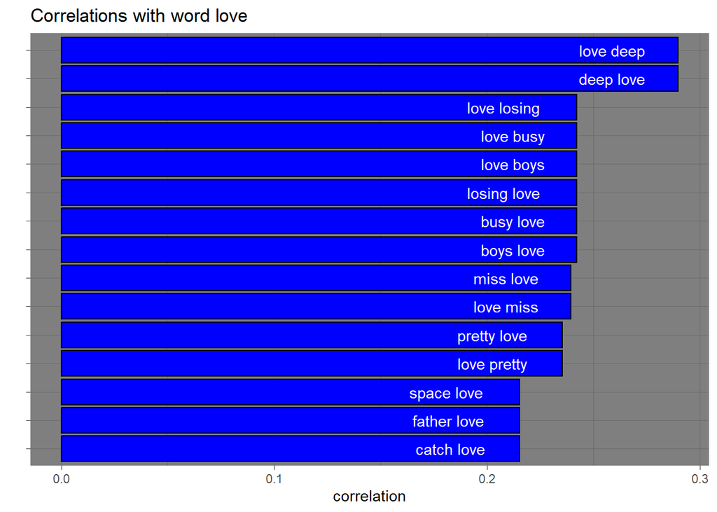

```r
cor %>%
  #filter
  filter(item1 == "love" | item2 == "love") %>%
  #sort in descending order
  arrange(desc(correlation)) %>%
  #merge columns together and filter for top 15 results
  unite(context, item1, item2, sep = " ") %>%
  slice(1:15) %>%
   ggplot()+
  #reorder by correlation coefficient
  aes(correlation, reorder(context,correlation))+
  #set bar colors
  geom_bar(stat = "identity", color = "black", fill = "blue")+
  theme_dark()+
  labs(y = " ", title = "Correlations with word love")+
  theme(axis.text.y = element_blank())+
  #include text labeling in white to contrast
  geom_text(aes(label = context), hjust = 1.5, color = "white")
```

There we go, these are the most correlated terms with the word “love” according to our phi coefficient. By far, the most frequent instances take place when love appears in the same context as “deep” followed by “losing” and “boys”. We are confirming that love for Taylor is usually linked to deep emotions for boys (so we can discard other forms of love such as family or friends) and, once again, we notice some correlation with words like “losing” or “miss” to stress this melancholic feeling of regret present in many of her songs.

## Sparcity and Time evolution

Up to now, we have been working with lyrics on a tidy format such that we operated one token per row in our data frame. As a closing section to our project, let´s plot a time evolution of the most relevant words for Taylor and mutate the data into DTM in order to explore the concept of *Sparcity*. Sparsity in text mining refers to the phenomenon where a large proportion of the terms in a document or corpus occur very infrequently or not at all. In other words, the majority of the terms have a frequency of zero or close to zero.

First, we will use our original lyrics data and unnest tokens just as we did at earlier stages of the study. We generate a new column accounting for the percentage of times a term is used in relation to the whole frequency of terms by year. This is done to standardize since one could find years in which Taylor had launched more than 10 songs and others in which she just introduced a new single. Whatever the case, we will group by year and plot the evolution of the usage of words “love”, “time” and “baby”:

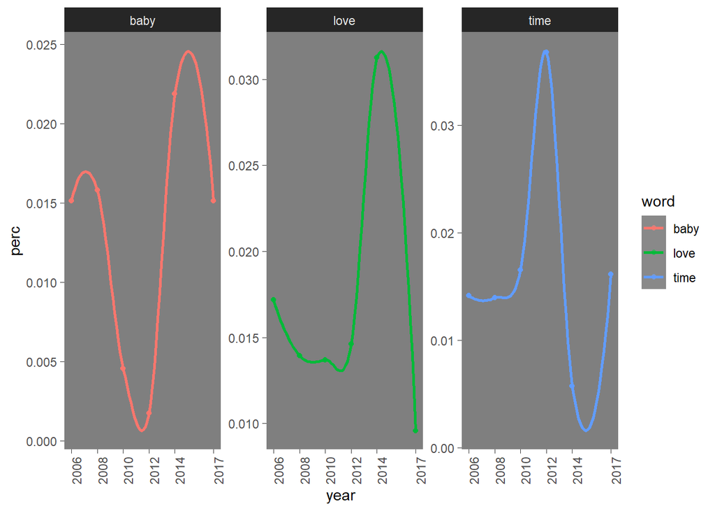

```r
lyrics %>%
  #Split all the tokens and care for punctuation
  unnest_tokens(word,lyric, drop = TRUE,
                "strip_punct" = TRUE) %>%
  #We select only the columns we are interested in
  select(album,track_title,year,word) %>%
  anti_join(stop_words) %>%
  count(year,word) %>%
  group_by(year) %>%
  #Generate new columns for total words and percentage usage
  mutate(total = sum(n), perc = n/total) %>%
  ungroup() %>%
  #we filter by our terms vector
  filter(word %in% c("love", "time", "baby")) %>%
  ggplot(aes(year, perc, color = word)) +
  geom_point() +
  geom_smooth(group = 1) +
  #facet the result by word
  facet_wrap(~ word, scales = "free_y") +
  labs(Title = "Temporal Frequency of Taylor´s Terms")+
  theme_dark()+
  #remove grid lines
  theme(panel.grid = element_blank(),
        axis.text.x = element_text(angle = 90))+
  scale_x_continuous(breaks=unique(lyrics$year))
```

Finally, we can explore *Sparcity* by year to understand better our previous plot:

```r
lyrics %>%
  #Split all the tokens and care for punctuation
  unnest_tokens(word,lyric, drop = TRUE,
                "strip_punct" = TRUE) %>%
  #We select only the columns we are interested in
  select(album,track_title,year,word) %>%
  anti_join(stop_words) %>%
  count(year,word) %>%
  #second we convert to the matrix: we use the cast function with the three columns needed
  cast_dtm(year, word, n)
```

```
## <<DocumentTermMatrix (documents: 6, terms: 1957)>>
## Non-/sparse entries: 3405/8337
## Sparsity           : 71%
## Maximal term length: 17
## Weighting          : term frequency (tf)
```

## Final Remarks

In this project, we have dealt with a text mining process to uncover and explain Taylor Swift´s writing style and analyse the evolution and trends of word frequencies, distinctiveness, Sparsity etc. However, notice we are just operating with text, but music has other factors which makes Taylor a very successful artist such as her voice, her music knowledge, the timing of song releases, the language of her songs etc. A future research topic which could contribute to our findings and enhance the proposed project could be to combine text mining techniques with other types of structured data such as floats or dates in order to search for potentially interesting relationships (e.g. Is the evolution of Taylor´s sentiment correlated with the amount of records sold? Is there a particular context or topic preferred by the audience? What songs have lasted for longer on the top 100 billboard and how can we account for this by resorting to text mining techniques? etc.)

Our word frequencies and counts revealed that terms such as “feel,” “kiss,” “home,” or “girl” follow were consistent with our previous analysis that Taylor Swift’s entire discography appears to be intended to express emotions related to girls, romance, and the feeling of being comfortable or at home. However, some other notable words such as “mad,” “forever,” “hate,” or “wrong” also appear, indicating that her songs also convey some degree of exasperation or pain.

However, an improved version of this technique was implied when dealing with tf_idf such that we observed how the word “fearless” was specific to the album with the same name, which was not that surprising. Additionally, words such as “careful”, “enchanted,” and “sparks” are unique to the album “Speak Now”. One can suggest that the album focuses on expressing a potentially perplexing or frustrating love experience, likely involving someone who has caused her some emotional turmoil. This theme is reflected in the album’s title, “Speak Now,” which invites her to speak her truth and share her story with the world. This was one of her top selling albums of all time.

When resorting to bigrams and phi correlation techniques, we established that the words most strongly correlated with “love” are “deep,” “losing,” and “boys.” The most frequent instances of these words occur in contexts where love is described as deep, followed by references to “losing” and “boys”. This suggests that, for Taylor Swift, love is typically associated with intense emotions towards boys, rather than other forms of love such as family or friends. Once again, according to the Phi Coefficient, these are linked to the notion of “losing” or “miss,” emphasizing the sorrowful feeling of regret that is often available in her songs.